# Predict Notebook

This notebook is used to test the performance of the trained model by specifying the experiment name used for training.

The notebook contains simulated and real world images, as well as a video recording from a dash camera. The labels are not available for the real world data and hence only visual inspection of the results is possible.

**NOTE**: The video playback for the last cell does not work in Mozilla Firefox. Please run the cell in Google Chrome or any other browser that uses the Chromium engine such as Microsoft Edge, Brave, etc.

```python
%load_ext autoreload

%autoreload 2
```

```python
%%javascript
IPython.OutputArea.prototype._should_scroll = function(lines) {
    return false;
}
//Above code disables scrollable cells. This useful while plotting figures that span multiple rows.
```

```python
# System Modules

import os
import matplotlib.pyplot as plt
import skvideo.io

import torch
from torch.utils.data import Dataset, ConcatDataset

from data.image_dataset import ImageDataset
from data.video_dataset import VideoDataset, VideoWriter
from model import Model, get_device
from network.unet import UNet
from utils.experiment import Experiment
from utils.visualization import play_notebook_video
```

### Creating an experiment perform predictions using trained model.

```python
# Open Experiment
exp = Experiment(name='test20', train=False)
cfg_path=exp.params['cfg_path']

# Initialize Model
model = Model(exp,net=UNet)
model.load_trained_model()
```

### Generate test set from simulation and run model for prediction

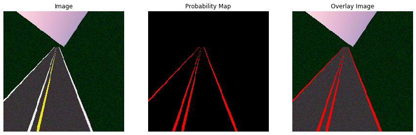

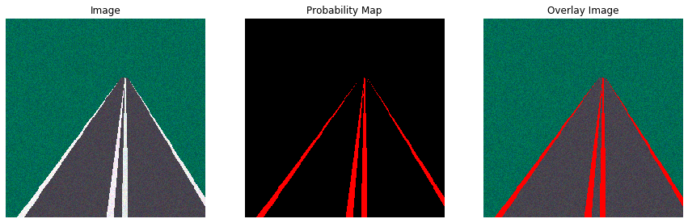

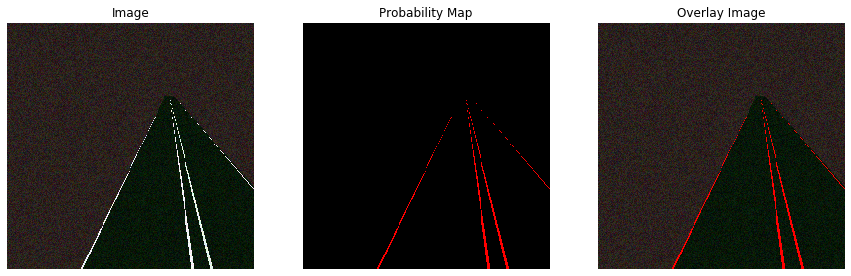

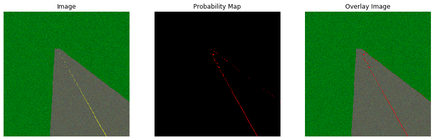

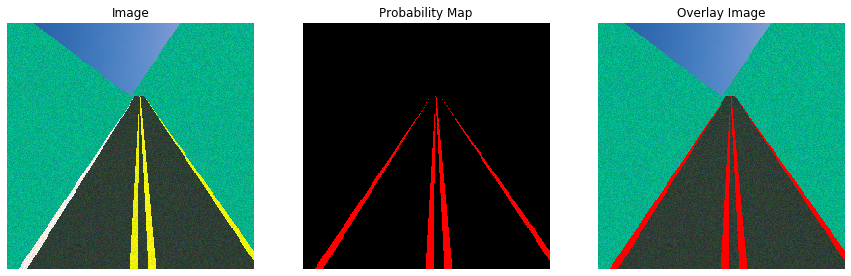

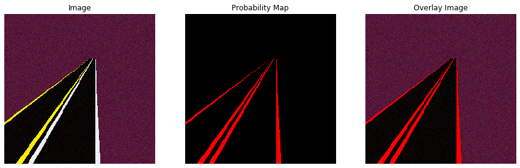

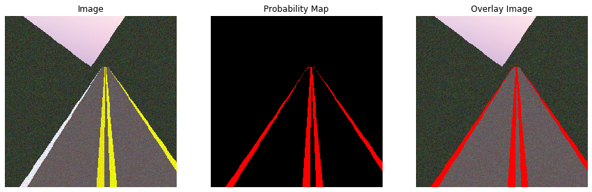

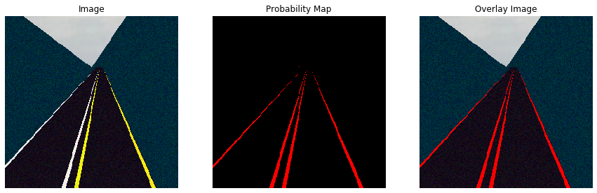

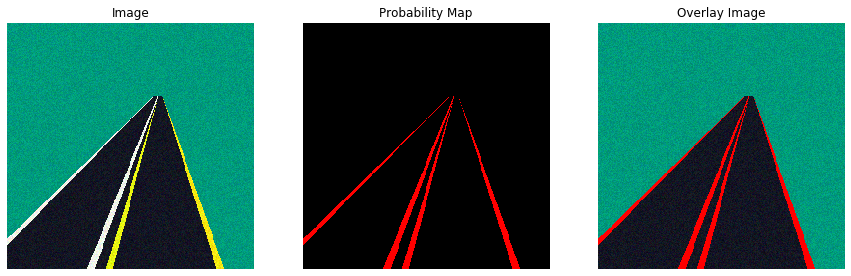

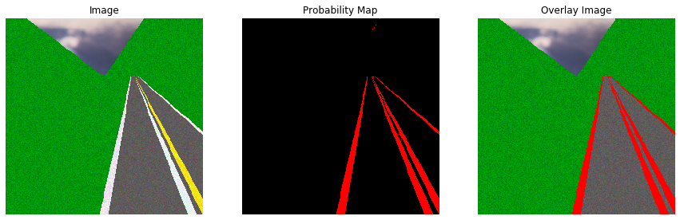

```python
predict_dataset = ImageDataset(dataset_name='TestSet18', size=10,
                               seed=49,cfg_path=cfg_path, is_train=False,)
predict_loader = torch.utils.data.DataLoader(dataset=predict_dataset,
                                                 batch_size=1,
                                             shuffle=False, num_workers=2)



for image, _ in predict_loader:
        model.predict(image,video_writer = None)
```

## Load test set containing real world no lane images and run model for prediction

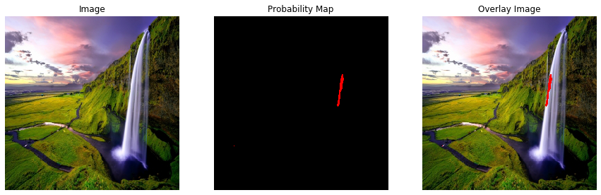

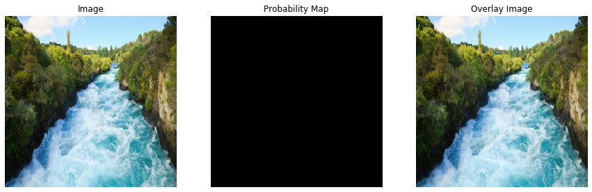

```python
predict_dataset = ImageDataset(dataset_name='Real_NoLane_Predict',
                               size=1, seed=234, cfg_path=cfg_path, is_train=False,)

predict_loader = torch.utils.data.DataLoader(dataset=predict_dataset,
                                                 batch_size=1,
                                                 shuffle=False, num_workers=2)
for image, _ in predict_loader:
        model.predict(image,video_writer = None)
```

### Load test set containing real world lane images and run model for prediction

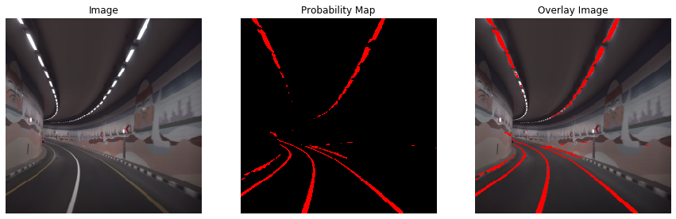

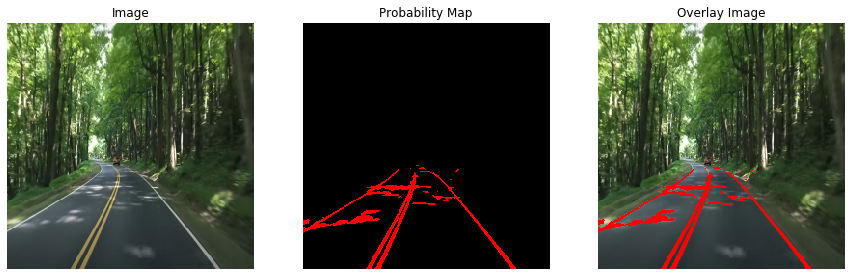

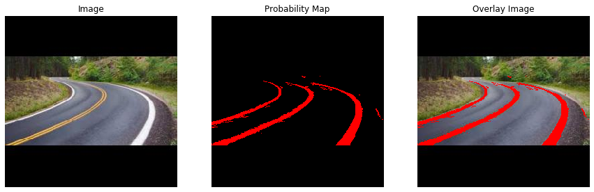

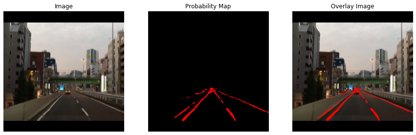

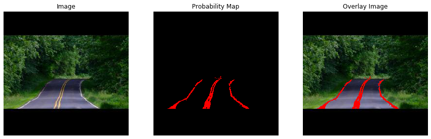

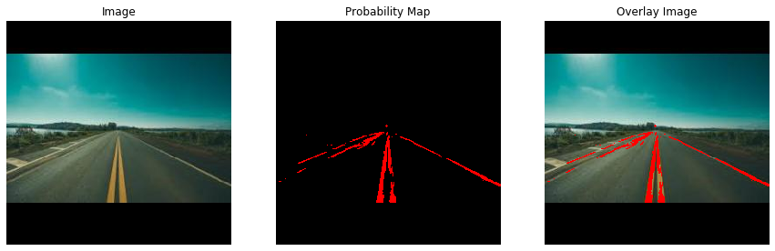

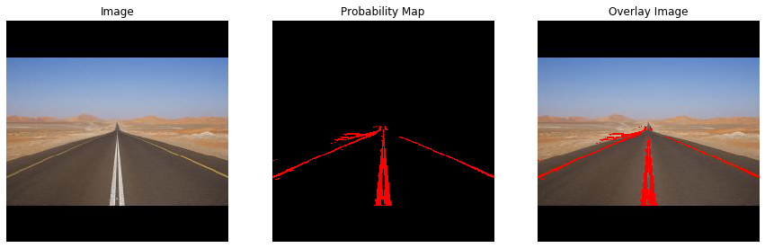

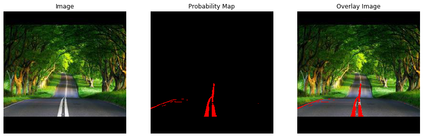

```python
predict_dataset_real=ImageDataset(dataset_name='Real_Lane_Predict',
                                  size=1, seed=234, cfg_path=cfg_path, is_train=False,)

predict_loader_real = torch.utils.data.DataLoader(dataset=predict_dataset_real,
                                               batch_size=2,
                                               shuffle=False,num_workers=2)


for image, _ in predict_loader_real:
        model.predict(image,video_writer = None)
```

### Predictions for video file

```python
video_predict_dataset=VideoDataset(folder_name='Video')
#video_predict_dataset=VideoDataset()
video_loader=torch.utils.data.DataLoader(dataset=video_predict_dataset,
                                               batch_size=1,
                                               shuffle=False)

with VideoWriter(exp) as vid_writer:
    for image,_ in video_loader:
            model.predict(image,video_writer = vid_writer)

pth =os.path.join(exp.params['output_data_path'],'outputvideo.mp4')
play_notebook_video(pth)
```

```
done
```

[video not shown]